# Linear Modeling in R

Clay Ford, Statistical Research Consultant, UVA Library

## Quick Intro to R Notebooks and R Markdown

This file was created in RStudio by going to File…New File…R Notebook.

To hide the output, click the Expand/Collapse output button. To clear results (or an error), click the “x”.

You can also press *Ctrl+Enter* (Win/Linux) or *Cmd+Return* (Mac) to run one line of code at a time (instead of the entire chunk).

Add a new R code chunk by clicking the *Insert Chunk* button on the toolbar or by pressing *Ctrl+Alt+I* (Win/Linux) or *Cmd+Option+I* (Mac).

## Exercise 0 (code along)

Insert a new R code chunk below and type/run the code: 22/7

## Linear Modeling with Simulated Data

Instead of using theory and formulas, let’s explore and review linear modeling using simulated data.

Below we assign to `x` the values 1 - 25. Then we generate `y` as a function of `x` using the formula `10 + 5*x`:

```r
x <- 1:25
y <- 10 + 5*x  # formula for a line
d <- data.frame(x, y)
plot(y ~ x, data = d)
```

10 is the intercept, 5 is the slope. `y` is completely determined by `x`. That is, `y = 10 + 5*x`.

Now let’s add some “noise” to our data by adding random draws from a Normal distribution with mean = 0 and a standard deviation = 10. That’s what the `rnorm` function does.

`set.seed(1)` ensures we all generate the same “random” data:

```r
set.seed(1)
noise <- rnorm(n = 25, mean = 0, sd = 10)
# Add the noise to 10 + 5*x and re-draw plot
d$y <- 10 + 5*x + noise
plot(y ~ x, data = d)
```

This data is the combination of two parts:

1. 10 + 5*x
2. rnorm(n = 25, mean = 0, sd = 10)

What if we were given this data and told to determine the process that generated it? In other words, work backwards and fill in the blanks:

1. __ + __*x
2. rnorm(n = 25, mean = 0, sd = ____)

*That’s basically what linear modeling/regression is*. You have some numeric response (or dependent) variable, and you want to find the model (or the formula) that generated the data.

Traditional linear modeling/multiple regression assumes the following (among others):

1. the formula is a weighted sum of predictors (eg, y = 10 + 5*x)
2. the noise is a random draw from a Normal distribution with mean = 0
3. the standard deviation of the Normal distribution is constant

Linear modeling tries to recover the weights in the first assumption (10 and 5) and the standard deviation in the 3rd assumption (10).

Let’s attempt to recover the data generating process for our data. For this we use the `lm()` function. We have to specify the formula for the first assumption. The 2nd and 3rd assumptions are built into `lm()`.

The formula “y ~ x” means we think the model is “y = intercept + slope*x”. (Unless we specify otherwise, this assumes we want to estimate an intercept.) This tells `lm()` to take our data and find the best intercept and slope. Notice this is the correct model!

When you use `lm` you’ll usually want to save the results to an object. Below I save it to “mod”. Then we view the results of the model using `summary()`

```r
mod <- lm(y ~ x, data = d)
summary(mod)
```

The model returns the following estimates:

1. 11.135 + 5.042 * x
2. rnorm(n = 25, mean = 0, sd = 9.7)

These are pretty close to the “true” values of 10, 5, and 10 we used to generate the data.

**In real life, we DO NOT KNOW the formula is part 1. The real data generation process will be far more complicated. The formula we propose will just be an approximation and may not be good.**

**In real life, we DO NOT KNOW if the Normality assumption or constant variance assumption of the noise is plausible.**

How can we evaluate our model formula?

We could use those estimates to generate data and see if they look similar to our original data. (Run entire chunk at once.)

```r
y2 <- 11.135 + 5.042*d$x + rnorm(25, 0, 9.7)
plot(y ~ x, data = d)
points(d$x, y2, col = "red")
```

That looks pretty good! Our model-generated data appears similar to our observed data.

We could also compare smooth density curves of the original and model-generated data. Smooth density curves are basically smooth versions of histograms. If we have a good model, data generated by our model should have a similar distribution to the original data. (Run entire chunk at once.)

```r
hist(d$y, freq = F) # freq = F means area of bars sums to 1
lines(density(d$y))
y2 <- 11.135 + 5.042*d$x + rnorm(25, 0, 9.7)
lines(density(y2), col = "red")
```

This looks good as well. The distribution of our model-generated data is very similar to our observed data. You should do this more than once, say 50 times, to ensure the model consistently generates data similar to the observed data. We show one way to do that later in the workshop.

Since we think our model is “good”, we might use it to make a prediction using the `predict()` function. The `interval = "confidence"` arguments says return a 95% CI.

What’s the expected mean of `y` when `x` is 10?

```r
predict(mod, newdata = data.frame(x = 10), interval = "confidence")
```

```
       fit     lwr      upr
1 61.55932 57.2126 65.90603
```

The expected mean of `y` when `x` = 10 is about 61.6 with a 95% CI of (57.2, 65.9).

**This is basic linear modeling in R:**

1. propose and fit model(s) using `lm()`
2. determine if the model is good and that assumptions hold
3. use the model to explain relationships or make predictions

## CODE ALONG #1

Let’s do some linear modeling with real data.

## Import data

Let’s look at the first few rows:

```r
head(homes)
```

Variable name definitions:

- *yearbuilt*: year house was built
- *finsqft*: size of house in number square feet
- *cooling*: ‘Central Air’ versus ‘No Central Air’
- *bedroom*: number of bedrooms
- *fullbath*: number of full bathrooms (toilet, sink and bath)
- *halfbath*: number of half bathrooms (toilet and sink only)
- *lotsize*: size of land on which home is located, in acres
- *totalvalue*: total assessed value of home and property
- *esdistrict*: the elementary school the home feeds into
- *msdistrict*: the middle school the home feeds into
- *hsdistrict*: the high school the home feeds into
- *censustract*: the census tract the home is located in
- *age*: of the house in years as of 2018
- *condition*: assessed condition of home (Substandard, Poor, Fair, Average, Good, Excellent)
- *fp*: indicator if house has fireplace (0=no, 1=yes)

## Linear Modeling with Real Estate Data

Let’s say we want to model the mean total value of a home as a function of various characteristics such as lot size, finished square feet, presence of central air, etc.

We have to propose a linear model. Unlike the previous example this is not simulated data for which we know the data generating process. How to propose a model? It helps to have some subject matter expertise.

Let’s fit a linear model using finsqft, bedrooms and lotsize. The plus (+) sign means “include” in model.

```r
m1 <- lm(totalvalue ~ finsqft + bedroom + lotsize, data = homes)
summary(m1)
```

The `coef()` function extracts the coefficients (or weights):

```r
coef(m1)
```

Some naive interpretation:

- each additional finished square foot adds about $284 to price
- each additional bedroom drops the price by $13,218 (?)
- each additional lot size acre adds about $4268 to price

Remember, the interpretation assumes all other variables are held constant! So adding a bedroom to a house, without increasing the lot size or finished square feet of the house, is estimated to drop the value of a home. Does this make sense?

Is this a “good” model? There are many statistical metrics to help evaluate this, such as R-squared. But let’s simulate data from the model and compare it to our observed data. A “good” model should generate data that looks similar to the original data.

Now let’s plot our simulated data with our observed data using smooth density plots. We use a for loop to add smooth density estimates of the 50 simulations. The syntax `sim1[[i]]` extracts column *i* as a vector. (Run entire chunk at once.)

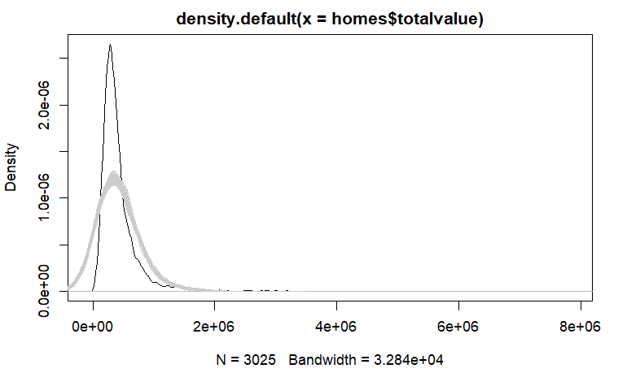

```r
plot(density(homes$totalvalue))
for(i in 1:50)lines(density(sim1[[i]]), col = "grey80")
```

(See end of notebook for how to create this plot using ggplot2 and for how to turn this into a function.)

This does not appear to be a good model. In fact some of our simulated values are negative!

Before we revise our model recall the main assumptions:

1. totalvalue can be modeled by a weighted sum: totalvalue = Intercept + finsqft + bedrooms + lotsize
2. noise/error is from Normal dist’n with mean 0
3. the SD of the Normal dist’n is constant

R provides some basic diagnostic plots to assess 2 and 3. Just call `plot` on your model object

```r
plot(m1)
```

How to interpret plots:

1. Residuals vs Fitted: should have a horizontal line with uniform and symmetric scatter of points; if not, evidence that SD is not constant
2. Normal Q-Q: points should lie close to diagonal line; if not, evidence that noise is not drawn from N(0, SD)
3. Scale-Location: should have a horizontal line with uniform scatter of point; (similar to #1 but easier to detect trend in dispersion)
4. Residuals vs Leverage: points outside the contour lines are influential observations. Leverage is the distance from the center of all predictors. An observation with high leverage has substantial influence on the fitted value.

By default the 3 “most extreme” points are labeled by row number. 2658 appears in all four plots. It’s a really big expensive home.

```r
homes[2658,]
```

These plots reveal that our assumptions of normally distributed residuals and constant SD are highly suspect.

What can we do?

Non-constant SD can be evidence of a mispecified model (ie, wrong model) or a very skewed response. Notice that our response is quite skewed:

```r
hist(homes$totalvalue)
```

We could try transforming `totalvalue` to a different scale. A common transformation is a log transformation, especially for positive amounts involving money. (Cannot log transform numbers less than or equal to 0.) When we log transform `totalvalue`, the distribution looks a little better.

```r
hist(log(homes$totalvalue))
```

```r
plot(m2)
```

But is this a “good model”? Is our proposed model of weighted sums good? Let’s simulate data and compare to observed data.

```r
sim2 <- simulate(m2, nsim = 50)
plot(density(log(homes$totalvalue)))
for(i in 1:50)lines(density(sim2[[i]]), lty = 2, col = "grey80")
```

This doesn’t look too bad!

Let’s say we’re happy with this model. How to interpret? The response is log transformed, so interpretation of coefficients changes. We first need to *exponentiate* and then interpret the effect as *multiplicative* instead of additive. Below we exponentiate using the `exp` function and then round to 4 decimal places.

```r
round(exp(coef(m2)), 4)
```

Some naive interpretations:

- each additional finished square foot increases price by 0.05%. Or divide by 100 to get each additional 100 finished square feet increases price by 5%. *NOTE: Multiplying a value by 1.0005 is the same as adding 0.05% to the value. Likewise, multiplying a value by 1.05 is the same as adding 5% to the value.*
- each additional bedroom increases price by about 4.4%
- each additional lot size acre increases price by about 0.47%

Again, these relationships assume all other variables are held constant.

Let’s review the summary output:

```r
summary(m2)
```

SUMMARY OVERVIEW

- Residuals section: quick assessment of residuals. Ideally 1Q/3Q and Min/Max will be roughly equivalent in absolute value.
- Coefficients: lists the estimated coefficients along with hypothesis tests for the null that each coefficient is 0. Est/SE = t-value.
- Residual standard error: estimate of the constant standard deviation of the normal dist’n of the residuals (noise)
- degrees of freedom: sample size - number of coefficients (3025 - 4)
- R-squared: proportion of variance explained
- F-statistic: overall test that all coefficients (except intercept) are 0.

All of the p-values refer to hypothesis tests that the coefficients are 0. Many statisticians and researchers don’t like these tests and prefer to look at confidence intervals.

```r
round(exp(confint(m2)), 4)
```

According to our model, each additional bedroom adds between 2% and 6% to the value of a home, assuming all else held constant.

## YOUR TURN #2

1. Insert a code chunk below and model `log(totalvalue)` as function of `fullbath` and `finsqft.` Call your model `m3`
2. Insert a code chunk below and check the diagnostic plots
3. How do we interpret the fullbath coefficient?
4. Insert a code chunk below and simulate data from the model and compare to the observed `totalvalue`. Does this look like a good model?

## Categorical predictors

Let’s include `hsdistrict` in our model. Does being in a particular high school district affect total value of a home? Here’s a quick tally:

```r
table(homes$hsdistrict)
```

These levels are not numbers, so how does R handle this in a linear model? It creates a *contrast*. This is a matrix of zeroes and ones. If you have K levels, you’ll have K-1 columns. In this case we’ll have two columns: one for Monticello HS and one for Western Albemarle HS. By default R takes whatever level comes first alphabetically and makes it the *baseline* or *reference* level.

This is called a *treatment contrast* and is the default in R.

```r
contrasts(factor(homes$hsdistrict))
```

A model with `hsdistrict` will have two coefficients: `Monticello` and `Western Albemarle`

- a home in Albemarle HS district gets two zeroes
- a home in Monticello HS district gets a one in the Monticello column
- a home in Western Albemarle HS district gets a one in the West Alb column

Let’s go ahead and fit our model. Our proposed model says “high school district has some relationship with total value of home”. (Our model may not be right.)

```r
m4 <- lm(log(totalvalue) ~ fullbath + finsqft + hsdistrict, data = homes)
summary(m4)
```

The coefficients for Monticello and Western Albemarle are in relation to Albemarle HS. To understand their effect we need to exponentiate.

```r
round(exp(coef(m4)), 4)
```

```
                (Intercept)                    fullbath
                107102.0186                      1.1755
                    finsqft        hsdistrictMonticello
                     1.0004                      0.9347
hsdistrictWestern Albemarle
                     1.1050
```

It appears that the value of a home in Western Albemarle will be about 11% higher than an equivalent home in Albemarle. Likewise it appears that the value of a home in the Monticello district will be about 7% less than an equivalent home in the Albemarle district.

## YOUR TURN #3

1. Insert a code chunk below and model `log(totalvalue)` as function of `fullbath`, `finsqft` and `cooling.` Call your model `m5`.
2. What is the interpretation of cooling? What is the baseline or reference level?

## Modeling Interactions

In our model above that included `hsdistrict` we assumed the effects were *additive*. For example, it didn’t matter what high school district your home was in, the effect of `bathroom` or `finsqft` was the same. It also assumed the effect of each additional `fullbath` was the same regardless of how big the house was, and vice versa. This may be too simple.

Interactions allow the effects of variables to depend on other variables. Again subject matter knowledge helps with the proposal of interactions. As we’ll see interactions make your model more flexible but harder to understand.

R makes it simple to include interactions in models. Just indicate an interaction between two variables by placing a colon (:) between them. Below we include 2-way interactions. (You can have 3-way and higher interactions but they’re very difficult to interpret.)

```r
m6 <- lm(log(totalvalue) ~ fullbath + finsqft + hsdistrict +
           fullbath:finsqft + fullbath:hsdistrict +
           finsqft:hsdistrict, data = homes)
summary(m6)
```

Interpretation is now much more difficult. We cannot directly interpret the *main effects* of `fullbath`, `finsqft` or `hsdistrict`. Why? Because they interact. What’s the effect of `finsqft`? It depends on `fullbath` and `hsdistrict`.

Are the interactions “significant” or necessary? Use the `anova` function to evaluate this question:

```r
anova(m6)
```

Just because an interaction is significant doesn’t necessarily mean it’s interesting or worthwhile. Nor can we infer anything about the nature of the interaction from the ANOVA table.

*Effect plots* can help us visualize and make sense of models with interactions. Let’s make one using the ggeffects package and talk about what it’s showing.

```r
library(ggeffects)
plot(ggpredict(m6, terms = c("fullbath", "hsdistrict")))
# place fullbath on x-axis, group by hsdistrict
```

What’s the effect of `fullbath`? It depends. It’s more dramatic in Western Albemarle and Monticello. Of course a lot of the difference comes at extreme values of `fullbath`. The “ribbons” around the lines are 95% confidence intervals.

What exactly was plotted? We can see by calling `ggpredict` without `plot`

```r
ggpredict(m6, terms = c("fullbath", "hsdistrict"))
```

`ggpredict` used our model to make `totalvalue` predictions for various values of `fullbath` in the three school districts, holding finsqft at 1828.

We can specify our values if we like. For example, make an effect plot for 1 - 5 bathrooms and hold `finsqft` at 2000:

```r
plot(ggpredict(m6, terms = c("fullbath[1:5]", "hsdistrict"),
          condition = c(finsqft = 2000)))
```

What about the effects of `finsqft` and `fullbath`? This is an interaction of two numeric variables. The second variable has to serve as a grouping variable when creating an effect plot. Below we set `fullbath` to take values 2 - 5 and `finsqft` to take values of 1000 - 4000 in steps of 500.

```r
# plot(ggpredict(m6, terms = c("finsqft", "fullbath")))
plot(ggpredict(m6, terms = c("finsqft[1000:4000 by=500]", "fullbath[2:5]")))
```

The effect of `finsqft` seems to taper off the more fullbaths a house has. But there are few large homes with 2 full baths, and likewise, few small homes with 5 full baths. Even though the interaction is “significant” in the model, it’s clearly a very small interaction.

## YOUR TURN #4

1. Insert a code chunk below and model `log(totalvalue)` as function of `fullbath`, `finsqft`, `cooling`, and the interaction of `finsqft` and `cooling`. Call your model `m7`. Is the interaction warranted?
2. Visualize the interaction using the `ggpredict` function. Perhaps use `[1000:4000 by=500]` to set the range of `finsqft` on the x-axis.

## Wrap-up

This was meant to show you the basics of linear modeling in R. Hopefully you have a better grasp of how linear modeling works.

What we did today works for *independent, numeric outcomes*. We had one observation per home and our response was `totalvalue`, a number. Our models returned expected *mean* total value given various predictors. This is a pretty simple design.

Things get more complicated when you have, say, binary responses or multiple measures on the same subject (or home). A non-exhaustive list of other types of statistical modeling include:

- generalized linear models (for binary and count responses)
- multinomial logit models (for categorical responses)
- ordered logit models (for ordered categorical responses)
- mixed-effect or longitudinal linear models (for responses with multiple measures on the same subject)
- survival models (for responses that measure time to an event)
- time series models (for responses that exhibit, say, seasonal variation over time)

**References**

- Faraway, J. (2005). *Linear Models in R*. London: Chapman & Hall.
- Fox, J. (2002). *A R and S-Plus Companion to Applied Regression*. London: Sage.
- Harrell, F. (2015). *Regression Modeling Strategies* (2nd ed.). New York: Springer.
- Kutner, M., et al. (2005). *Applied Linear Statistical Models* (5th ed.). New York: McGraw-Hill.
- Maindonald J., Braun, J.W. (2010). *Data Analysis and Graphics Using R* (3rd ed.). Cambridge: Cambridge Univ Press.

## Nonlinear Effects

So far we have assumed that the relationship between a predictor and the response is linear (eg, for a 1-unit change in a predictor, the response changes by a fixed amount). That assumption can sometimes be too simple and not realistic. Fortunately there are ways to fit non-linear effects in a linear model.

Here’s a quick example of simulated non-linear data: a 2nd degree polynomial.

```r
x <- seq(from = -10, to = 10, length.out = 100)
set.seed(3)
y <- 1.2 + 2*x + 0.9*x^2 + rnorm(100, sd = 10)
nl_dat <- data.frame(y, x)
plot(y ~ x, nl_dat)
```

Clearly a straight-line model will not work for this data. The relationship between x and y is not adequately summarized by a straight line model.

If we wanted to try to “recover” the weights we used in simulating this data we could fit a polynomial model:

```
nlm1 <- lm(y ~ poly(x, degree = 2, raw = TRUE), data = nl_dat)
```

However, the recommended approach to fitting non-linear effects is to use *natural splines* instead of polynomials. Natural splines essentially allow us to fit a series of cubic polynomials connected at knots located in the range of our data.

The easiest option is to use the `ns()` function from the splines package. `ns` stands for “natural splines”. The second argument is the degrees of freedom (`df`). It may help to think of `df` as the number of times the smooth line changes directions.

Frank Harrell states in his book *Regression Model Strategies* that 3 to 5 `df` is almost always sufficient. His basic advice is to allocate more `df` to variables you think are more important.

Let’s see how it work with our simulated data.

```r
library(splines)
nlm2 <- lm(y ~ ns(x, df = 2), data = nl_dat)
```

Here’s one way to see the fitted line.

```r
plot(ggpredict(nlm2, terms = "x"), add.data = TRUE)
```

Let’s return to the homes data and fit a non-linear effect for `finsqft` using a natural spline with 5 `df`. Below we also include `hsdistrict` and `lotsize` and allow `finsqft` and `hsdistrict` to interact.

```r
nlm3 <- lm(log(totalvalue) ~ ns(finsqft, 5) + hsdistrict + lotsize +
           ns(finsqft, 5):hsdistrict,
         data = homes)
```

The `anova` function allows us to assess the non-linear effect and the interaction:

```r
anova(nlm3)
```

The summary output is impossible to interpret,

```r
summary(nlm3)
```

Effect plots are our only hope for understanding this model.

```r
plot(ggpredict(nlm3, terms = c("finsqft[1000:3000 by=250]", "hsdistrict")))
```

The effect of `finsqft` on `totalvalue` seems more dramatic in Western Albemarle once you go beyond 1500 sq ft.

Does the model simulate data similar in distribution to the observed data?

```r
sim4 <- simulate(nlm3, nsim = 50)
plot(density(log(homes$totalvalue)))
for(i in 1:50)lines(density(sim4[[i]]), col = "grey80")
```

We can (and should) still check model assumptions of constant variance and normal residuals.

```r
plot(nlm3)
```

Homes 12, 40, 963 and 1810 seem to stand out. Let’s have a look.

```r
h <- c(12, 40, 963, 1810)
homes[h,c("totalvalue", "finsqft", "lotsize")]
```

Homes 12 and 40 are very low in totalvalue and the model way overpredicts their values. Home 963 has a massive totalvalue with 0 acres of lotsize. Home 1810 is on 611 acres and that value has a high leverage on its fitted value.

```r
cbind(obs = homes$totalvalue[h], fit = exp(fitted(nlm3)[h]))
```

## YOUR TURN #5

1. Insert a code chunk below and model `log(totalvalue)` as function of `finsqft` with a natural spline of 5 `df`, `cooling`, and the interaction of `cooling` and `finsqft` (natural spline of 5 `df`). Call your model `nlm4`.
2. Use the `anova` function to check whether the interaction appears necessary. What do you think?
3. Create an effect plot of `finsqft` by `cooling`. Maybe try `[1000:5000 by=250]` for the range of values for `finsqft`.
4. Check the graphical model assumptions using the `plot` function.
5. How well does the distribution of the model-generated data match the distribution of the observed data?

## ggplot2 code for creating plot of simulated data

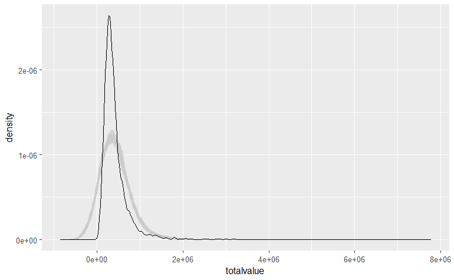

## How to make a function for simulating and plotting data for a linear model

**Base R**

We basically copy and paste the original code in between the curly braces of the `function()` function. We call the function `plot_sims` but you can name it whatever you like. The changes are to the model name and number of simulations. We generalize those with arguments: `mod` and `nsim`. When we fit a model with `lm`, the data is stored with the model object by default and can be accessed as mod$model. The first column contains the model response, so we can access it with `[,1]` and use it to draw the density of the observed data.

```r
# ORIGINAL CODE

# sim1 <- simulate(mod, nsim = 50)
# plot(density(homes$totalvalue))
# for(i in 1:50)lines(density(sim1[[i]]), col = "grey80")

plot_sims <- function(mod, nsim){
  sim1 <- simulate(mod, nsim = nsim)
  plot(density(mod$model[,1]))
  for(i in 1:nsim)lines(density(sim1[[i]]), col = "grey80")
}
# try the function
plot_sims(m1, nsim = 20)
```

**ggplot2**

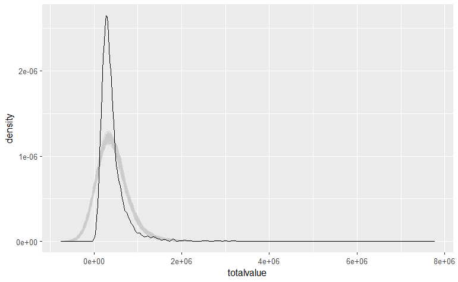

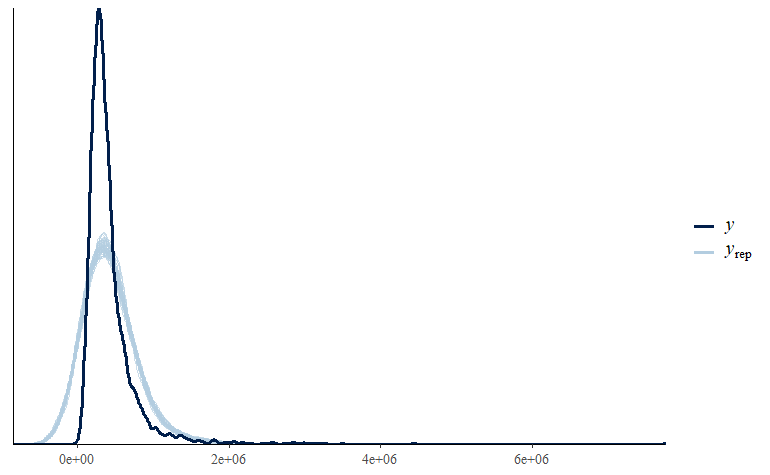